# Lab 6 Income as Dependent

Kyle Landolt

April 11, 2015

# Homework

Your homework assignment is to analyze the prestige data, using “income” as the dependent variable. That is, develop a regression model that helps to explain the income in an occupation, using any of the other data in the the Prestige data set as a potential predictor. Describe your methodology from beginning to end. I have done this using Prestige as the dependent variable, and you should follow along with that before continuing.

```r
library(spdep)
library(dplyr)
```

```r
library(ggplot2)
library(GGally)
library(car)
data(Prestige)
```

[output not shown]

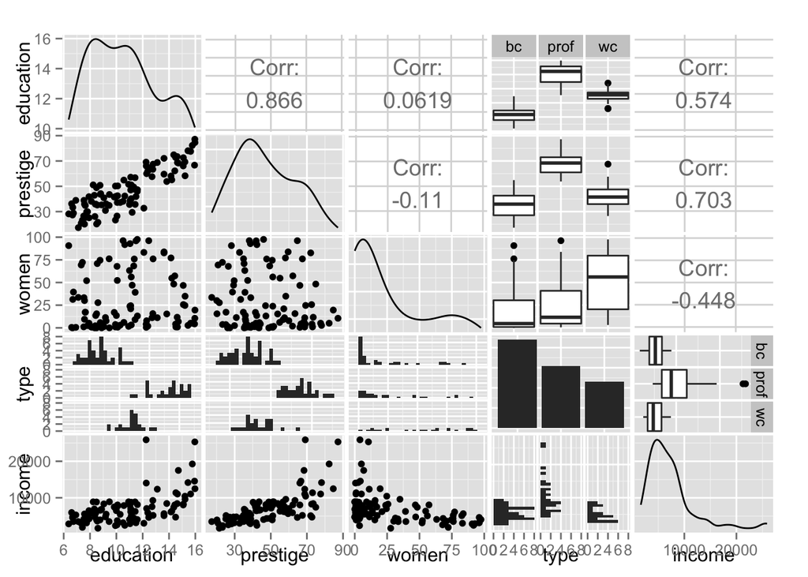

```r
ggpairs(Prestige %>% filter(!is.na(type)) %>% select(education, prestige, women, type, income))
```

I started to analyze the relationship of income as a dependent factor by using the ggpairs function to quickly observe the bivariate relationship of income to the other independent factors. I note the following:

1. If the solid, smoothed black line of income represents its distribution, then I notice that it seems to be positively skewed.
2. There doesn’t seem to a good linear relationship of income to any covariates, although the correlation coefficient for income to prestige was fairly high at +0.703. Education has a relatively high correlation coefficient too at 0.574. It’s also noted that income to women have a negative correlation coefficent, possibly showing that women are paid less than males.
3. The relationships of income to education and prestige both appear exponential.

I do not want to remove any covariates at the moment for risk of creating a confounding variable, so I will do a multivariate regression to see the results.

```r
reg0 <- lm(income ~ type + education + prestige + women, data=Prestige)
summary(reg0)
```

```
##
## Call:
## lm(formula = income ~ type + education + prestige + women, data = Prestige)
##
## Residuals:
##     Min      1Q  Median      3Q     Max
## -7761.6  -958.6  -302.6   754.2 14206.1
##
## Coefficients:
##             Estimate Std. Error t value Pr(>|t|)
## (Intercept)  420.524   1957.349   0.215 0.830365
## typeprof     324.193   1463.093   0.222 0.825131
## typewc       235.331    984.774   0.239 0.811661
## education    116.434    275.226   0.423 0.673248
## prestige     140.605     35.365   3.976 0.000139 ***
## women        -53.505      9.663  -5.537 2.89e-07 ***
## ---
## Signif. codes:  0 '***' 0.001 '**' 0.01 '*' 0.05 '.' 0.1 ' ' 1
##
## Residual standard error: 2619 on 92 degrees of freedom
##   (4 observations deleted due to missingness)
## Multiple R-squared:  0.6362, Adjusted R-squared:  0.6164
## F-statistic: 32.17 on 5 and 92 DF,  p-value: < 2.2e-16
```

The initial multivariate regression has prestige and women as significant relationships. I can check for lineary using the component + residual plots.

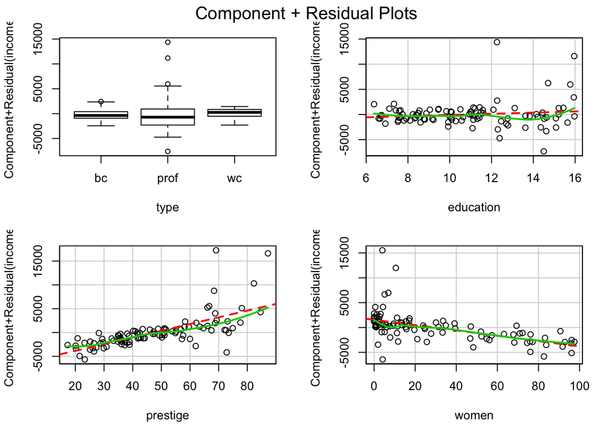

```r
crPlots(reg0)
```

After checking the plots I noticed that it’s still clear that education and prestige have an exponential relationship. Because I don’t want to transform my dependent variable first, I will first try to transform education and prestige to exp(education) and exp(prestige). I do this so I won’t have to directly transform income in hopes of maintaning my significant relationship of income to women.

```r
reg1 <- lm(income ~ type + exp(education) + exp(prestige) + women, data=Prestige)
summary(reg1)
```

```
##
## Call:
## lm(formula = income ~ type + exp(education) + exp(prestige) +
##     women, data = Prestige)
##
## Residuals:
##     Min      1Q  Median      3Q     Max
## -6430.9 -1114.0  -236.6   702.2 15602.6
##
## Coefficients:
##                  Estimate Std. Error t value Pr(>|t|)
## (Intercept)     6.489e+03  4.133e+02  15.699  < 2e-16 ***
## typeprof        3.924e+03  7.554e+02   5.195 1.23e-06 ***
## typewc          1.635e+03  7.120e+02   2.297 0.023889 *
## exp(education)  4.784e-04  1.918e-04   2.495 0.014396 *
## exp(prestige)   1.529e-34  3.813e-35   4.010 0.000123 ***
## women          -5.896e+01  9.038e+00  -6.524 3.66e-09 ***
## ---
## Signif. codes:  0 '***' 0.001 '**' 0.01 '*' 0.05 '.' 0.1 ' ' 1
##
## Residual standard error: 2494 on 92 degrees of freedom
##   (4 observations deleted due to missingness)
## Multiple R-squared:   0.67,  Adjusted R-squared:  0.6521
## F-statistic: 37.36 on 5 and 92 DF,  p-value: < 2.2e-16
```

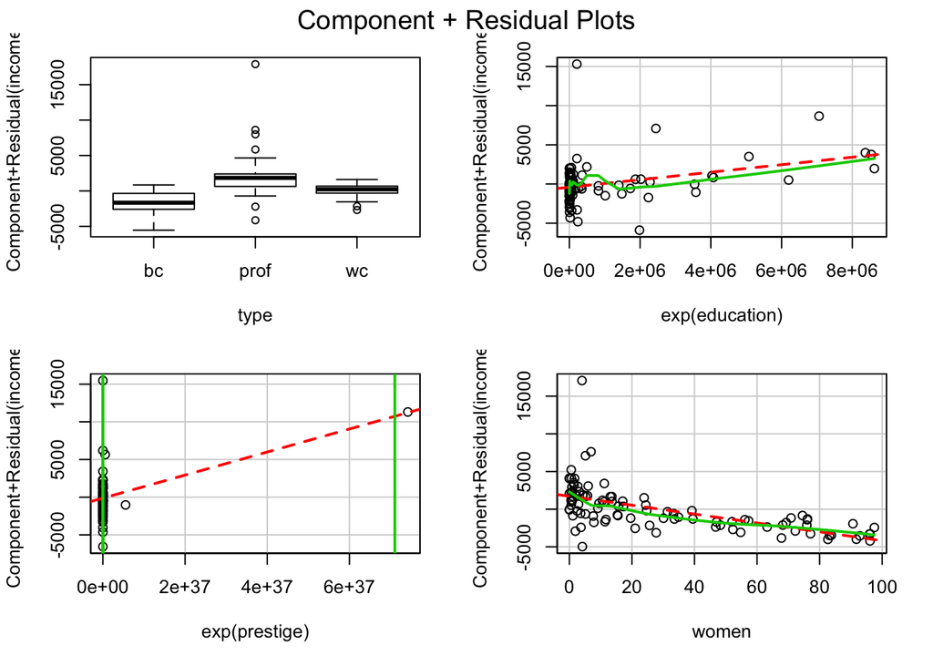

```r
crPlots(reg1)
```

The summary of this regression shows all the regressed independent variables as significant with women as the only negative coefficient. Looking at the component + residual plots, the exp(prestige) independent variable does not express the linear relationship so desired. The Adjusted R^2 value is also only 0.6521. I will now only log(income) and observe the results:

```r
reg2 <- lm(log(income) ~ type + education + prestige + women, data=Prestige)
summary(reg2)
```

```
##
## Call:
## lm(formula = log(income) ~ type + education + prestige + women,
##     data = Prestige)
##
## Residuals:
##      Min       1Q   Median       3Q      Max
## -0.99209 -0.09787  0.02141  0.13192  0.80961
##
## Coefficients:
##               Estimate Std. Error t value Pr(>|t|)
## (Intercept)  7.8720323  0.1811233  43.462  < 2e-16 ***
## typeprof    -0.0136776  0.1353873  -0.101    0.920
## typewc       0.0707760  0.0911261   0.777    0.439
## education    0.0076315  0.0254681   0.300    0.765
## prestige     0.0207481  0.0032725   6.340 8.42e-09 ***
## women       -0.0084655  0.0008942  -9.467 3.01e-15 ***
## ---
## Signif. codes:  0 '***' 0.001 '**' 0.01 '*' 0.05 '.' 0.1 ' ' 1
##
## Residual standard error: 0.2423 on 92 degrees of freedom
##   (4 observations deleted due to missingness)
## Multiple R-squared:  0.7953, Adjusted R-squared:  0.7842
## F-statistic:  71.5 on 5 and 92 DF,  p-value: < 2.2e-16
```

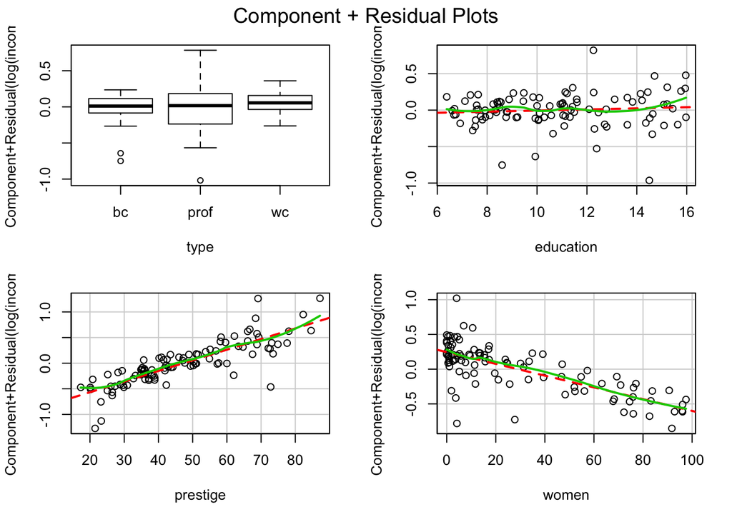

```r
crPlots(reg2)
```

Because we logged the dependent variable, income, now the regression is interpreted as 1 unit change in x is now 100 $beta$ % change in y.

After logging income, I see that there are significant relationships with prestige and women and the R^2 value has become 0.7842. The component residual lines are more satisfactory, although I’m still not completely happy with education because of the inconsistency towards the right tail.

I would to now see with the reg2 model how education will change according to a prediction of log(income) holding the values of prestige and women at a constant.

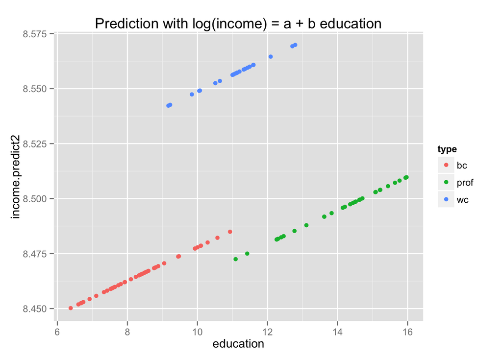

```r
# First, copy the data, but then fix eduation and income to set values
pred.data <- Prestige %>% mutate(prestige=50, women=60)
# Now, do the predictions
pred.data$income.predict2 <- predict(reg2, newdata = pred.data)
# And plot
ggplot(pred.data) + geom_point(aes(x=education, y=income.predict2, color=type))+
  labs(title = "Prediction with log(income) = a + b education" )
```

You can clearly see how education and the predicted log income relates to types. However, I will now try to run a linear regression excluding education to see how that will affect the adjusted R^2 value.

```r
reg3 <- lm(log(income) ~ type + prestige + women, data=Prestige)
summary(reg3)
```

```
##
## Call:
## lm(formula = log(income) ~ type + prestige + women, data = Prestige)
##
## Residuals:
##      Min       1Q   Median       3Q      Max
## -0.99146 -0.09986  0.01444  0.12951  0.79522
##
## Coefficients:
##               Estimate Std. Error t value Pr(>|t|)
## (Intercept)  7.9157744  0.1066949  74.191  < 2e-16 ***
## typeprof     0.0118842  0.1046159   0.114    0.910
## typewc       0.0869789  0.0729894   1.192    0.236
## prestige     0.0213068  0.0026763   7.961 4.08e-12 ***
## women       -0.0084547  0.0008891  -9.510 2.23e-15 ***
## ---
## Signif. codes:  0 '***' 0.001 '**' 0.01 '*' 0.05 '.' 0.1 ' ' 1
##
## Residual standard error: 0.2411 on 93 degrees of freedom
##   (4 observations deleted due to missingness)
## Multiple R-squared:  0.7951, Adjusted R-squared:  0.7863
## F-statistic: 90.24 on 4 and 93 DF,  p-value: < 2.2e-16
```

I see now that my adjusted R^2 value increased from 0.7842 to 0.7863. This in interesting in terms of model simplification. I would like to run an ANOVA between the linear model with education and the new linear model without education to see if there is a signficiant difference between the two.

```r
anova(reg2, reg3)
```

```
## Analysis of Variance Table
##
## Model 1: log(income) ~ type + education + prestige + women
## Model 2: log(income) ~ type + prestige + women
##   Res.Df    RSS Df  Sum of Sq      F Pr(>F)
## 1     92 5.4021
## 2     93 5.4074 -1 -0.0052724 0.0898 0.7651
```

After running the ANOVA I notice that there is no significant difference between the two models as the Pr(>F) is greater than 0.05. Because of this, I choose not to drop education.

One last analysis I would like to see is the redidual plots of my finale regression model explaining log(income) as the dependent variable.

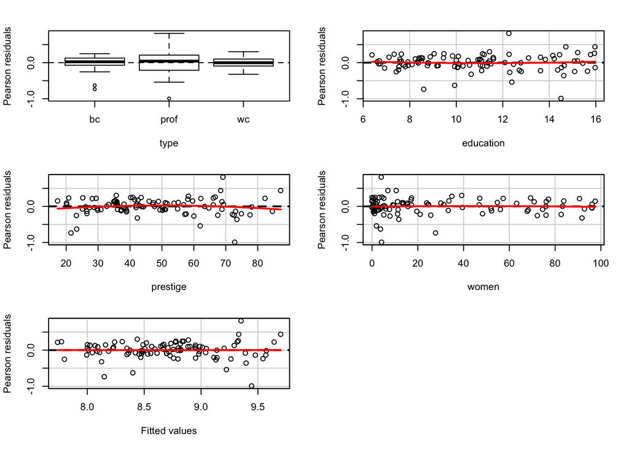

```
##            Test stat Pr(>|t|)
## type              NA       NA
## education      0.608    0.545
## prestige      -1.085    0.281
## women         -0.199    0.842
## Tukey test     0.019    0.985
```

```r
residualPlots(reg2)
```

I see that the residual plots for my regression are very linear and I’m satisfied with the outcome of my model. I choose to not do any further analysis based on these findings.